# Subaru_Regression

James Paul

2023-05-03

```r
d.subaru <- read_tsv("subaru_data.txt") %>%
  mutate(odometer = as.numeric(odometer),
         year = as.numeric(year))
```

Naturally, I started this analysis by reading in the Subaru data.

```r
d.prep <- d.subaru %>%
  recipe() %>%
  step_other(model,threshold = 500) %>%
  step_impute_knn(year, impute_with = imp_vars(odometer, price)) %>%
  step_impute_knn(model, impute_with = imp_vars(odometer, price, year))%>%
  step_log(odometer) %>%
  step_mutate(year=substr(as.character(year),1,4)) %>%
  step_mutate(year=as.numeric(year))%>%
  step_mutate(year=ifelse(year>=1990 & year<=2023,year,NA_real_))%>%
  step_mutate(odometer=substr(as.character(odometer),1,6))%>%
  step_mutate(odometer= as.numeric(odometer))%>%
  step_mutate(odometer=odometer*10000)%>%
  step_mutate(title_status=if_else(title_status %in% c("clean","lien"),title_status, NA_character_))%>%
  step_mutate(cylinders=if_else(cylinders %in% c("4 cylinders","6 cylinders","8 cylinders"),cylinders,NA_character_))%>%
  step_mutate(price= as.numeric(as.character(price)))%>%
  step_mutate(price=ifelse(price>=1000 & price<=100000, price, NA_real_))%>%
  step_naomit(price, model, odometer, year, cylinders)%>%
  prep() %>%
  juice()
```

After reading in the data, it was apparent that there was a fair amount of cleaning that needed to be done to the data, the recipe above is all of the step functions I used to clean the data in a way I found useful. The one step above that I thought may be unusual or controversial is where I imputed car model, I wanted to limit the number of NA values in that variable. One of the variables I used to create the imputation data was also imputed (year). I considered this and felt that although this could lead to more inaccuracy, it was useful to get an idea of what model car were likely talking about. The consequences of being wrong are also low and whether the KNN model predicted the car model correctly would be apparent after contacting someone about the vehicle in question if interested.Another thing I did here was omit all of the NA values from price, model, odometer, year, and cylinders; in order for the model I create later to run properly.

```r
set.seed(042723)
all.sub.idx <- sample(seq_len(nrow(d.prep)),size = floor(0.8*nrow(d.prep)), replace=F)
sub.train <- d.prep[all.sub.idx,]
sub.test <- d.prep[-all.sub.idx,]
```

Next, I split the data into training and test datasets. I went with the default here, so there is 75% of the data in the training dataset and 25% of the data in the testing dataset.

```r
set.seed(42723)
sub.splits <- initial_split(d.prep)
d.train <- training(sub.splits)
d.test <- testing(sub.splits)
filtered.train <- d.train %>% filter(!is.infinite(odometer))
filtered.test <- d.test %>% filter(!is.infinite(odometer))

sub.model <- linear_reg()%>%
  set_engine("lm")

sub.fit <- sub.model %>%
  fit(price~model+odometer+year+cylinders, data=filtered.train)
```

At this point, I was ready to create a model, and that’s what the code above does. I also had to filter out the -inf values due to the linear regression function not working when infinite values are present. I chose linear regression for this analysis because its the technique I’m the most familiar with and because it is good at making predictions; the goal of this analysis. Knowing what limited amount I do about cars, I used model, odometer, year, and number of cylinders as my predictor variables.

```r
predict(sub.fit,filtered.test)
```

```
## # A tibble: 3,298 × 1
##     .pred
##     <dbl>
##  1  7950.
##  2 17649.
##  3 14010.
##  4  7714.
##  5 17619.
##  6  -545.
##  7  3504.
##  8 12383.
##  9  1753.
## 10  3123.
## # … with 3,288 more rows
```

```r
filtered.test <- filtered.test %>%
  mutate(prediction= predict(sub.fit,filtered.test) %>%
  pull(.pred))
```

After creating a good model, I used predict to test my model with the test data set aside previously. I was satisfied with the predictions I got from the model at face value, they looked to be reasonable. I did some further analysis below on the predicitons my model created.

```r
filtered.d.prep <- d.prep %>% filter(!is.infinite(odometer))

sub.fit.comp <- sub.model %>%
  fit(price~model+odometer+year+cylinders, data=filtered.d.prep)

predict(sub.fit.comp,filtered.d.prep)
```

```
## # A tibble: 13,201 × 1
##     .pred
##     <dbl>
##  1  7951.
##  2 17911.
##  3 14006.
##  4  7716.
##  5  9519.
##  6 17881.
##  7  9720.
##  8  4938.
##  9  5370.
## 10 15716.
## # … with 13,191 more rows
```

```r
filtered.d.prep <- filtered.d.prep %>%
  mutate(prediction= predict(sub.fit.comp,filtered.d.prep) %>%
  pull(.pred))

filtered.d.prep$residuals <- filtered.d.prep$price - filtered.d.prep$prediction
```

Once I came to the conclusion I was satisfied with the model I created, I applied the model to the entire dataset. Once I had a predicted price for the whole dataset I was able to easily create a residuals column in the dataset.

```r
best.deals <- filtered.d.prep %>% filter(residuals >= -2500 & residuals <= -2000)

arrange(best.deals, residuals)
```

```
## # A tibble: 585 × 13
##    post_id make  model  year odome…¹ vin   title…² cylin…³ crumb…⁴ crumb…⁵ price
##      <dbl> <fct> <fct> <dbl>   <dbl> <fct> <fct>   <fct>   <fct>   <fct>   <dbl>
##  1  6.96e9 <NA>  fore…  2002  122350 2C8G… clean   6 cyli… minnea… anok/c…  1250
##  2  6.85e9 <NA>  fore…  2004  120810 <NA>  clean   6 cyli… minnea… dakota…  2950
##  3  6.62e9 suba… other  2013  113100 4S4W… clean   6 cyli… atlanta atlanta 14999
##  4  6.64e9 suba… other  2013  113100 4S4W… clean   6 cyli… atlanta atlanta 14999
##  5  6.70e9 suba… outb…  2011  117730 <NA>  clean   6 cyli… minnea… anok/c… 10400
##  6  6.70e9 suba… outb…  2011  117730 <NA>  clean   6 cyli… minnea… anok/c… 10400
##  7  6.71e9 suba… outb…  2011  117730 <NA>  clean   6 cyli… minnea… anok/c… 10400
##  8  6.71e9 suba… outb…  2011  117730 <NA>  clean   6 cyli… minnea… anok/c… 10400
##  9  6.70e9 suba… outb…  2011  117730 <NA>  clean   6 cyli… minnea… anok/c… 10400
## 10  6.85e9 suba… other  2009  116260 <NA>  lien    4 cyli… minnea… hennep…  9500
## # … with 575 more rows, 2 more variables: prediction <dbl>, residuals <dbl>,
## #   and abbreviated variable names ¹odometer, ²title_status, ³cylinders,
## #   ⁴crumb_area, ⁵crumb_subarea
```

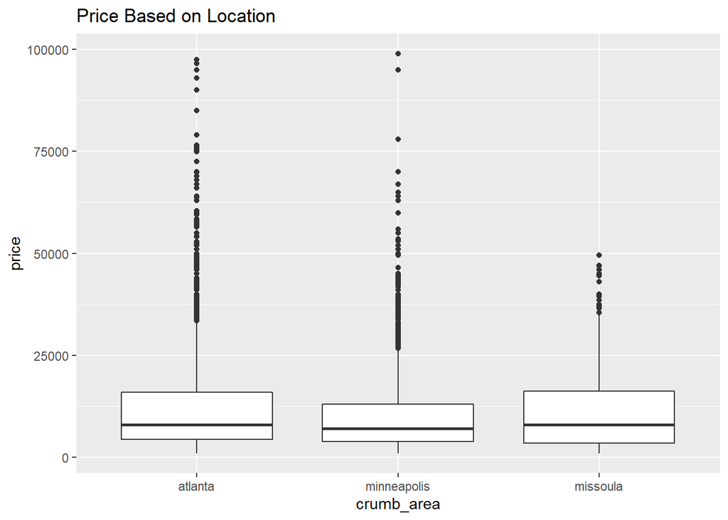

```r
ggplot(filtered.d.prep, aes(x= crumb_area, y= price))+
  geom_boxplot()+
  ggtitle("Price Based on Location")
```

Next I looked at the price of subarus based on location, and according to this data and the boxplot above, Minneapolis has the cheaper cars compared to Missoula or Atlanta

```r
cor.test(filtered.d.prep$price, filtered.d.prep$year)
```

```
##
##  Pearson's product-moment correlation
##
## data:  filtered.d.prep$price and filtered.d.prep$year
## t = 60.519, df = 13199, p-value < 2.2e-16
## alternative hypothesis: true correlation is not equal to 0
## 95 percent confidence interval:
##  0.4526002 0.4793090
## sample estimates:
##       cor
## 0.4660608
```

```r
cor.test(filtered.d.prep$price, filtered.d.prep$odometer)
```

```
##
##  Pearson's product-moment correlation
##
## data:  filtered.d.prep$price and filtered.d.prep$odometer
## t = -26.972, df = 13199, p-value < 2.2e-16
## alternative hypothesis: true correlation is not equal to 0
## 95 percent confidence interval:
##  -0.2446617 -0.2123256
## sample estimates:
##        cor
## -0.2285567
```

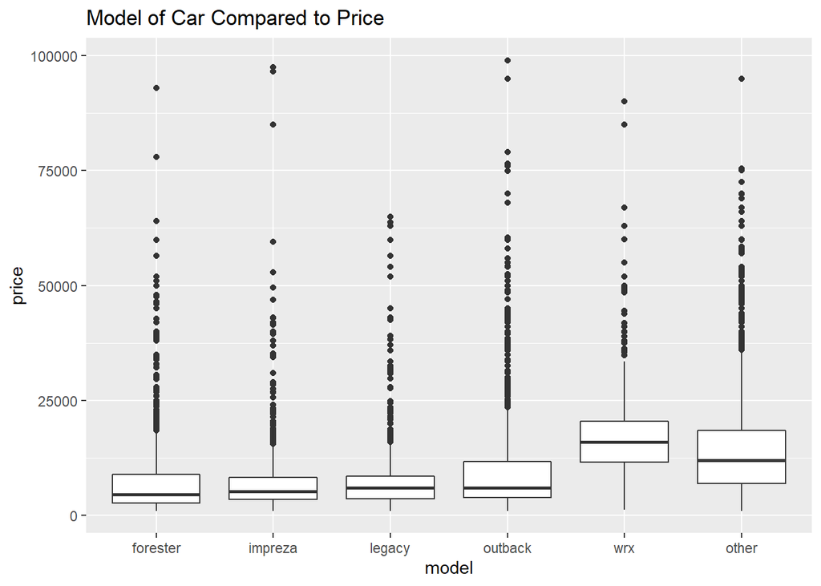

```r
ggplot(filtered.d.prep, aes(x=model, y= price)) +
  geom_boxplot()+
  ggtitle("Model of Car Compared to Price")
```

Finally, the last thing I did for this analysis was looked at the correlation between price and year, price and mileage, and I created a boxplot to compare model and price. The correlation between price and year in this data was nearly right in the middle, it was a positive correlation of 0.47, which is what we would expect, the newer the car the more expensive it will be. Conversely, the correlation between price and mileage was a fairly week negative correlation of -0.23. This is also along the lines of what we would expect, as mileage goes up, price tends to decrease. Lastly, the boxplot comparing price to model of car is interesting to look over, the price of most of the models is comparable. The one model that does tend to be more expensive though is the subaru WRX.